# Mid-term Progress Presentation Data Science Project

Cheuk Hang Ng

29/7/2022

# The project

- Dataset: 3700 storms occured in Atlantic Ocean between 1979 and 2015
- Aims:
  - Explore the dataset: exploratory data analysis
  - Model the strength, presence or absence of storms
  - Study rapid intensification
  - Predict rapid intensification of storms

# Exploratory Data Analysis (EDA)

The objective of EDA:

- Uncover the underlying structure of the dataset
- Find interesting relations among the variables
- Detect outliers or anomalous instances

Why is it important?

-> Understand patterns within data

-> Choosing appropriate statistical models or machine learning methods

# The data

3700 storm instances, maximum of 400 records

1. Day
2. Hour
3. Month
4. Year
5. Longitude
6. Latitude
7. Wind speed
8. Potential speed
9. Pressure
10. Wind shear

## The variables

Initially, the data have different shapes and are needed to be cleaned before we carry out the EDA.

For example, the day dataset:

```
##      V1 V2 V3 V4 V5 V6 V7 V8 V9 V10 V11 V12 V13 V14 V15 V16 V17 V18 V19 V20 V21
##   1: 12  9 23 30 17 21  8 11 19  25  29  19  25  10  23   7  23  20  12  11   3
##   2: 12  9 23 30 17 21  8 11 19  25  29  19  25  10  23   7  23  20  12  11   3
##   3: 12  9 23 30 17 21  8 11 19  25  29  19  25  10  23   7  23  20  12  11   3
##   4: 13  9 23 30 17 21  8 11 20  25  29  19  25  10  24   7  23  20  12  11   3
##   5: 13  9 23 30 17 21  8 11 20  25  29  19  25  10  24   7  23  20  12  11   3
##  ---
## 396:  0  0  0  0  0  0  0  0  0   0   0   0   0   0   0   0   0   0   0   0   0
## 397:  0  0  0  0  0  0  0  0  0   0   0   0   0   0   0   0   0   0   0   0   0
## 398:  0  0  0  0  0  0  0  0  0   0   0   0   0   0   0   0   0   0   0   0   0
## 399:  0  0  0  0  0  0  0  0  0   0   0   0   0   0   0   0   0   0   0   0   0
## 400:  0  0  0  0  0  0  0  0  0   0   0   0   0   0   0   0   0   0   0   0   0
##      V22 V23 V24 V25 V26 V27 V28 V29 V30 V31 V32 V33 V34 V35 V36 V37 V38 V39
##   1:  12   2   9  18  17  30  13  26   8  17  21   9   1   5  17  22  12  24
##   2:  12   2   9  18  17  30  13  26   8  17  21   9   1   5  17  22  12  24
```

[output cut: 3477 more lines]

# Data cleaning

Dimensions of dataframes

The first step is to unify the shapes of our data.

```
## [1] "Shape of day dataframe before: "
```

```
## [1]  400 3700
```

```
## [1] "Shape of pressure dataframe before: "
```

```
## [1] 3700  400
```

```
## [1] "Shape of day dataframe after: "
```

```
## [1] 3700  400
```

```
## [1] "Shape of pressure dataframe after: "
```

```
## [1] 3700  400
```

## Null values

We use NA (null value symbol in R) to replace the zeros in the dataset. Although it will lead to some information loss, it is worth to do so as we can separate the real data and null values.

# Functions for data cleaning

We defined some handy functions that would help us during the data cleaning process

## Longitude degree transformation

Transforming the longitude data so that the values are ranged from -180 degree to 180 degree

```r
#for longitude, we modify the value so that the range is [-180, 180]
degree <- function(x){
    ifelse(x > 180 , x - 360 , x)
}

longitude <- setDT(as.data.frame(sapply(longitude, degree)))
```

## Summary function

This function is used to statistically summarise a variable to a dataframe with arguments chosen from mode, minimum, maximum, mean (or average), standard deviation, first quartile, third quartile, median (or second quartile) or range.

```r
#sample snippet of the function
get_stat <- function(x, ...){
    ...
    for (i in list(...)){
        if (tolower(i) == "mode"){
            col <- apply(x, 1, mfv, na_rm = TRUE)
            col <- sapply(col, "[[", 1)
            name = paste0(deparse(substitute(x)), "_", i)
            result_df[name] <- col
        }
        ...
    ...
    return (result_df)
}
```

## Filter function

This function filters a dataframe with condition(s) on columns and returns a list of storm IDs which fulfill the condition(s)

```r
get_ID <- function(df, column, op, value, ...){
  arguments <- list(...)
  f <- match.fun(match.arg(op, choices = c('<', '>', '==', '>=', '<=')))
  ...
  else if {
    df %>%
    add_rownames() %>%
    filter(f(!!sym(column),value)) -> temp
    for(i in seq(from=1, to=length(arguments), by=3)){
      f <- match.fun(match.arg(arguments[[i+1]], choices = c('<', '>', '==', '>=', '<=')))

      temp %>%
      filter(f(!!sym(arguments[[i]]), arguments[[i+2]])) -> temp
    }
    temp %>%
    `[[`("rowname") %>%
    as.numeric() -> output
    return (output)
  }
}
```

# Summary dataframe

Using the summary function defined before, we created a dataset summary dataframe and variable summary dataframes.

Dataset summary dataframe:

```
##   day_mode hour_mode month_mode year_mode latitude_mean latitude_min
## 1       13         2         10      1979      19.91342        9.859
## 2       10         6          9      1979      26.10721       11.099
## 3        1         6          9      1979      23.55349        8.069
## 4        1         2          8      1979      30.42317       10.840
## 5       17         2         10      1979      19.63328       11.542
##   latitude_max latitude_range longitude_mean longitude_min longitude_max
## 1       51.050         41.191      -62.14568        -72.31       -54.870
## 2       50.758         39.659      -57.20643        -81.82         2.572
## 3       60.156         52.087      -43.07199        -70.94         8.038
## 4       58.868         48.028      -47.44608        -61.35         7.611
## 5       41.049         29.507      -76.21590        -80.88       -72.590
##   longitude_range speed_mean speed_min speed_max speed_range p_int_mean
## 1          17.440   36.15432      8.98     46.91       37.93   156.8171
## 2          84.392   45.41371      8.94    103.45       94.51   122.0440
## 3          78.978   43.55229      8.94     81.10       72.16   131.4515
## 4          68.961   45.42137     10.60     93.46       82.86   121.7562
## 5           8.290   31.05638      8.96     45.98       37.02   154.0000
##   p_int_min p_int_max p_int_range pressure_mean pressure_min pressure_max
## 1     28.22    179.23      151.01      998.4189       989.82       1008.8
## 2      9.49    171.28      161.79      995.4430       946.90       1008.8
## 3      0.04    177.02      176.98      995.9953       967.38       1008.8
## 4      0.04    158.37      158.33      993.0597       957.09       1008.1
## 5     52.71    180.09      127.38      999.6575       991.01       1008.8
##   pressure_range shear_mean shear_min shear_max shear_range
## 1          18.98  16.078581      2.05     29.66       27.61
## 2          61.90  10.629686      0.30     34.19       33.89
## 3          41.42  11.249314      2.56     23.67       21.11
## 4          51.01   8.287374      0.54     28.19       27.65
## 5          17.79  14.543333      3.80     25.89       22.09
```

## Variable summary dataframes

Example: speed summary dataframe

```
##    speed_mean speed_min speed_max speed_range
## 1    36.15432      8.98     46.91       37.93
## 2    45.41371      8.94    103.45       94.51
## 3    43.55229      8.94     81.10       72.16
## 4    45.42137     10.60     93.46       82.86
## 5    31.05638      8.96     45.98       37.02
## 6    18.70511      8.93     29.39       20.46
## 7    50.41613      8.94     99.37       90.43
## 8    27.90037      8.93     36.81       27.88
## 9    37.75388      9.94     62.42       52.48
## 10   32.96802      8.92     59.69       50.77
```

# Exploratory data analysis

## Correlation plot

A correlation plot can be used as a general guide on the relationships between variables, with visualised strength of correlations.

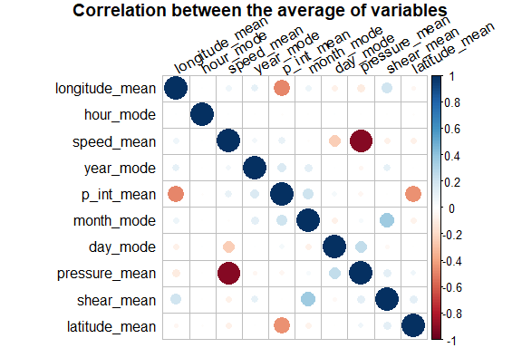

## Data visualisation

Univariate data visualisation

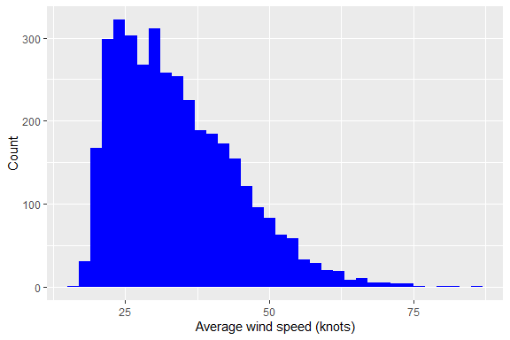

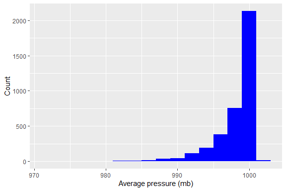

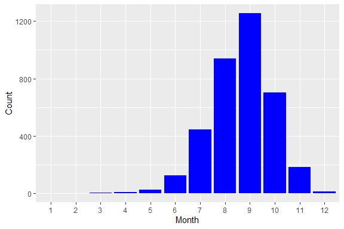

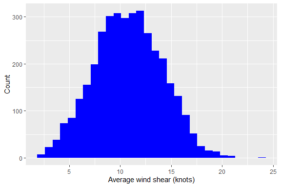

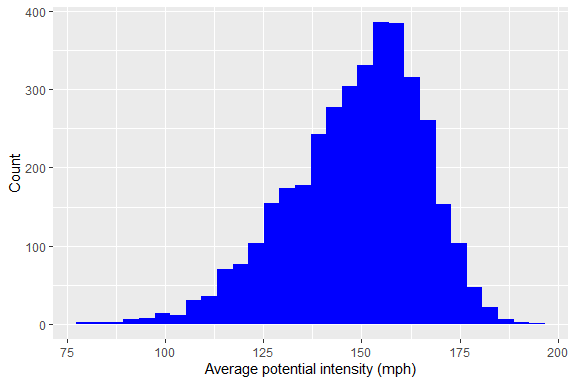

Wind speed and pressure being the major features of a storm, it is worth to explore their relationship

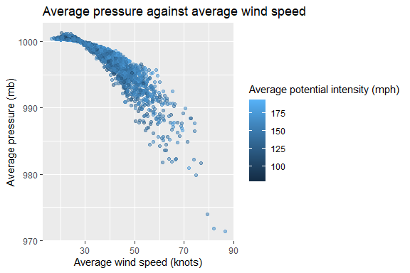

A non-linear inverse relation is observed between average wind speed and average pressure.

## Data visualisation

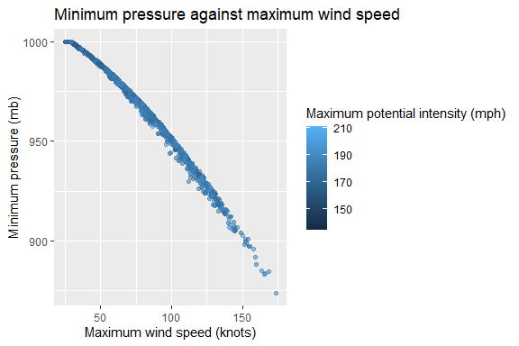

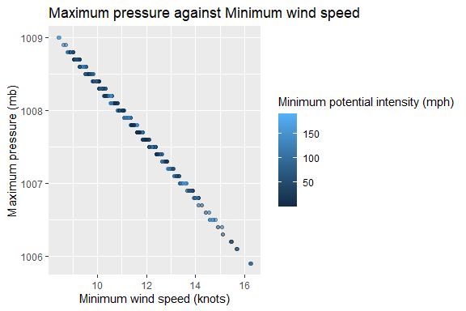

By plotting the extrema of these two variables, we obtained a linearly inversed relation.

## Data visualisation

We are also interested in the strength as well as the life time of storms by month.

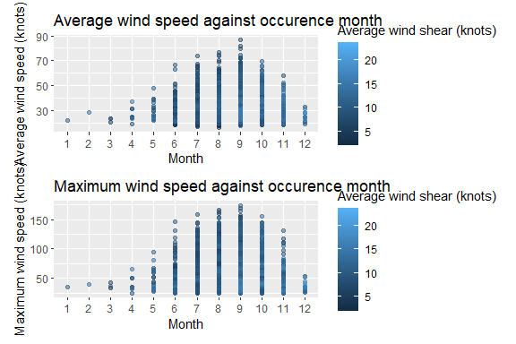

Storms with high maximum wind speed and high average wind speed are occurred mostly between July and October.

## Data visualisation

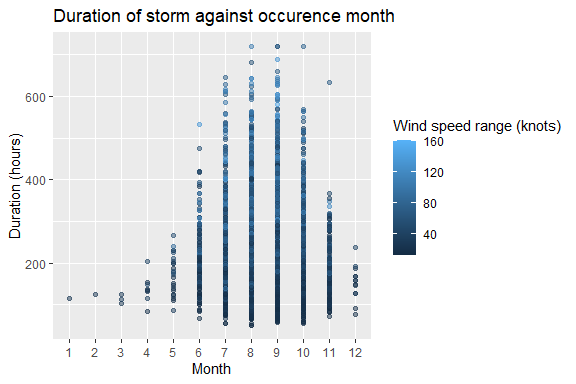

The distribution of life time of storms is similar to that of average/ maximum wind speed.

## Data visualisation

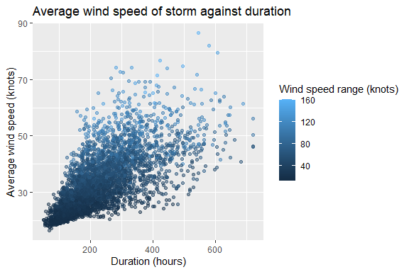

A weak proportionate relation is observed between duration, average wind speed and wind speed range.

# Storm tracks visulisation

We randomly picked 100 storms from the dataset and visualised their tracks:

[interactive chart not shown]

No clear pattern is found.

# Storms clustering and clustered EDA

Using algorithms to cluster the storms is a good way to analyse the dataset.

It helps us to identify storms that behave similarly.

## K-means clustering

At this stage, we applied k-means algorithm to cluster the storms.

- Easy to apply
- Easy to visualise

## Choice of number of clusters

Good clustering result depends on the choice of number of clusters when using k-means algorithm.

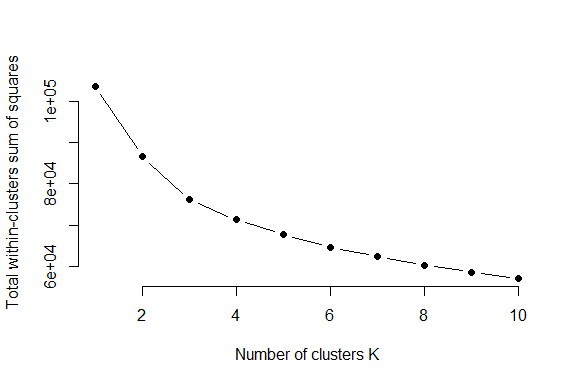

We can see that the decreasing rate of the loss function started to fall when k = 3. By the Elbow method, we chose 3 to be the number of clusters.

## Choice of number of cluster

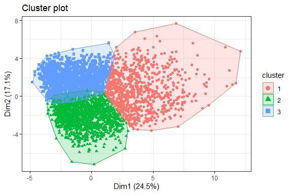

From the cluster plot, we can see that when k = 3 the boundaries are quite clear.

## Data visualization by cluster

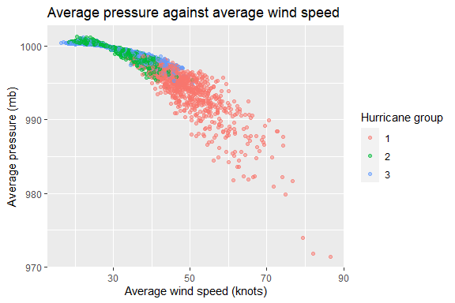

## Data visualization by cluster

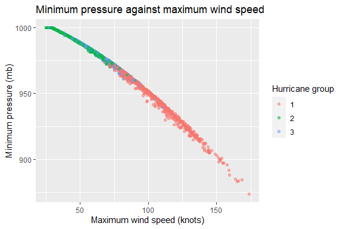

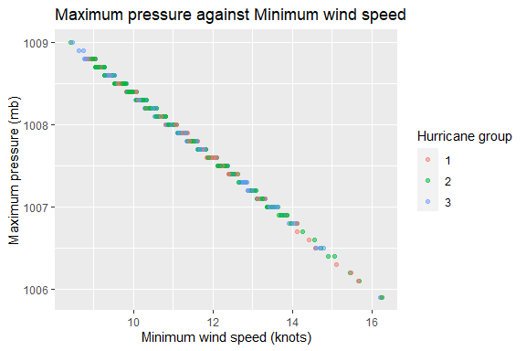

We can see that group 1 storms have greater maximum wind speed and smaller minimum pressure, but the maximum pressure to minimum wind speed ratios are similar for all three clusters.

## Data visualization by cluster

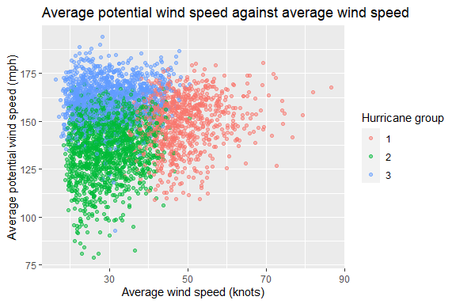

Another variable that differs the clusters.

## Data visualization by cluster

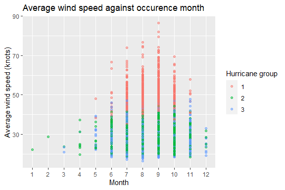

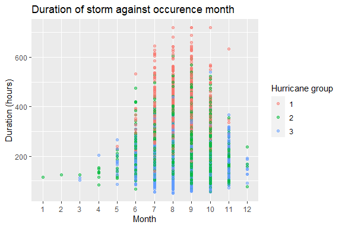

## Data visualization by cluster

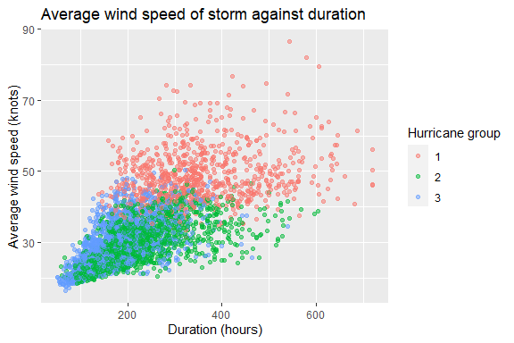

Group 2 storms have slightly longer life time than group 3.

## Clustered storm tracks visulisation

[interactive chart not shown]

Random sample storm tracks from group 1.

## Clustered storm tracks visulisation

[interactive chart not shown]

Random sample storm tracks from group 2.

## Clustered storm tracks visulisation

[interactive chart not shown]

Random sample storm tracks from group 3.

# Summary

- The project
- Data cleaning
- Data overview
- Data visualisation
- Clustered data visualisation

## Future works

- Predict strength, absence/ presence of storms
  - with existing data
  - with extra data (optional)
- Research paper reading: rapid intensification
- Model rapid intensification of storms